# reporting-templates

## Table of content

- Purpose
- How to use the App
  - Pre-requisites
  - Download the repository
  - Start the App
- Operating instructions
  - Introduction
  - Side bar
  - Tab “General”
  - Tab “Objectives”
  - Tab “Acquisition”
  - Tab “Pre-processing”
  - Tab “Abbreviations”
  - Tab “Report”
- How to adapt the App
- How to contribute
- License

# Purpose

This repository contains a **Shiny App** that guides users to **create a report for microscope images acquired at the Imaging Platform at LEIZA ([IMPALA](https://www.leiza.de/forschung/infrastrukturen/labore/impala)) with all the necessary metadata.**

Once all fields are entered, **the report can be exported to an ODS or XLSX file**.

**This report can and should be published together with the image data.** While publishing them as a supplementary material to a paper is OK, I recommend publishing everything in open access on an online repository like [Zenodo](https://zenodo.org/), [Figshare](https://figshare.com/) or [OSF](https://osf.io/) for easy and long-term accessibility. Additionally or alternatively, the report could be attached to a protocol, for example on [protocols.io](https://www.protocols.io/).  
For more details, **check my repo** [**publish-micro-image**](https://github.com/ivan-paleo/publish-micro-image).

The App is designed for the instruments available at the [IMPALA](https://www.leiza.de/forschung/infrastrukturen/labore/impala) and currently includes only the digital microscope (Zeiss Smartzoom 5) and the upright light microscope + LSCM (Zeiss Imager.Z2 Vario + LSM 800 MAT). More instruments will be added later.

If you would like to adapt the App to your instrument(s), check the sections How to adapt the App, How to contribute and License.

# How to use the App

I am planning to make the App available online on a server, but the App can currently only be run locally.

## Pre-requisites

The Shiny App is written in [Shiny](https://shiny.posit.co/) using [RStudio](https://posit.co/products/open-source/rstudio/), so you first need to download and install [R](https://www.r-project.org/) and [RStudio](https://posit.co/download/rstudio-desktop/). But fear not, **no knowledge of R/Rstudio is needed to run the App**!

## Download the repository

There are two ways to get the App: 1. Download my [GitHub repository](https://github.com/ivan-paleo/reporting-templates/archive/refs/heads/main.zip) or its latest [release](https://github.com/ivan-paleo/reporting-templates/releases) as a ZIP archive, and unzip it.  
2. [Fork and clone](https://happygitwithr.com/fork-and-clone.html) my GitHub repository.

## Start the App

1. Open the file reporting-templates.Rproj with RStudio.
2. Open the file `reporting-templates/app.R` from within RStudio by clicking on it in the `Files` panel.

[figure not shown]

> *Open the App from within RStudio.*
3. Run the App by clicking on the button `Run App` in the top right corner.

[figure not shown]

> *Run the App from within RStudio.*
4. The App will open in a new RStudio window. Alternatively, click on `Open in Browser` at the top to open the App within your favorite browser (Firefox, Chrome…). It does not make much difference, though, whether the App is opened in RStudio or in the browser.

[figure not shown]

> *App freshly opened (no input yet).*
5. Enter the information as explained in the following section (Operating instructions).

# Operating instructions

## Introduction

- In a strict sense, none of the fields are required. Yet, it is important that **you fill as many fields as possible**. Unedited fields will be filled with default values, so make sure you change them in case you did not apply default values.
- Some information that will be included in the report (see tab “Report”) is hard coded and does not depend on your input because it depends on the hardware only. Because of that (and other things), make sure you **use the latest version of the App**.
- **Every entered information summarizes all acquisitions about which you are reporting.** Therefore, do not fill the forms for every single acquisition bur rather for all acquisitions of a project. Metadata for every acquisition should be made accessible with the acquisition files themselves (see repo publish-micro-image).
- While it is possible to jump from any tab to any other, conditional input (i.e. input based on other input) might not update correctly. Therefore, I recommend that you **start in the side bar and then fill in every tab from left (“General”) to right (“Pre-processing”)**. The tab “Report” can be consulted any time to check how the output will look like.
- **You can save the settings for one instrument at a time.**
- **Refer to the instrument’s user manual if you need information about the settings.**

## Side bar

**Enter your name and select the instrument you used from the list.**  
Start again at the tab “General” if you switch to another instrument.

[figure not shown]

> *Side bar*

## Tab “General”

**Select the software you used from the list and enter the version(s).**  
Make sure you specify the full details of the version including hot fixes (HF).  
If you used more than 1 software packages, enter the versions in the same order as the software packages and separate them with semi-colons **without** space (e.g. “v12 HF5;v3 HF2”).

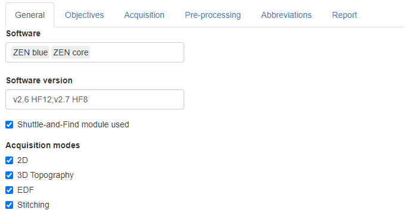

> *General tab for the Axio Imager.Z2 Vario + LSM 800 MAT.*

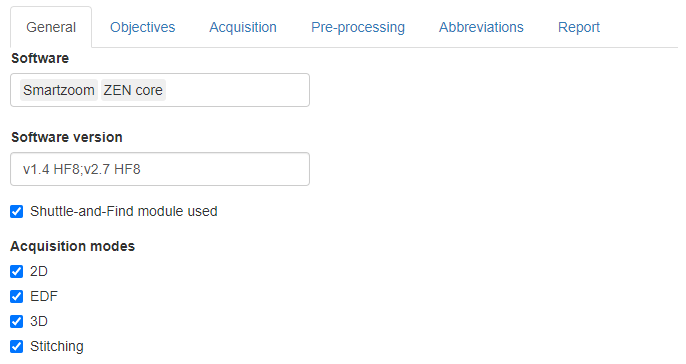

> *General tab for the Smartzoom 5.*

## Tab “Objectives”

**Select from the list how each objective has been used.**  
On the Axio Imager.Z2 Vario + LSM 800 MAT:

- Several uses can be assigned to every objective. To do so, click on every relevant use from the list.
- After selection, click on a use and press “DELETE” to unassign it. Make sure that at least one use is assigned to each objective (select “Not used” if you have not used a given objective).

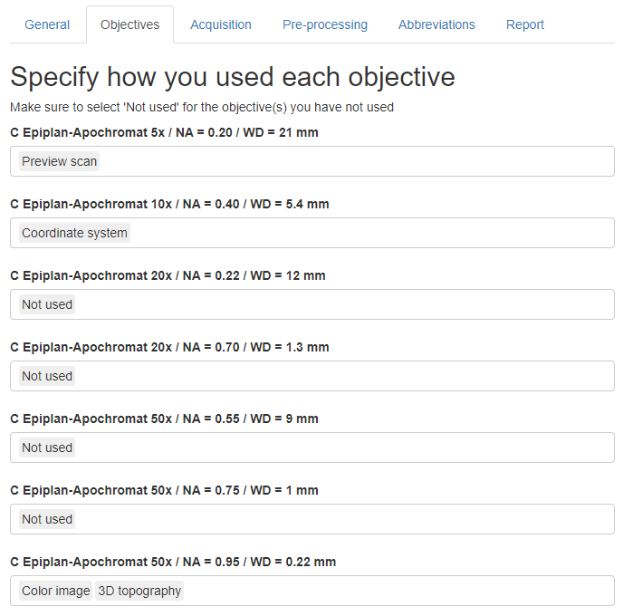

> *Objectives tab for the Axio Imager.Z2 Vario + LSM 800 MAT.*

On the Smartzoom 5: by default, none of the objectives has been used, so make sure you assign a use to at least one objective.

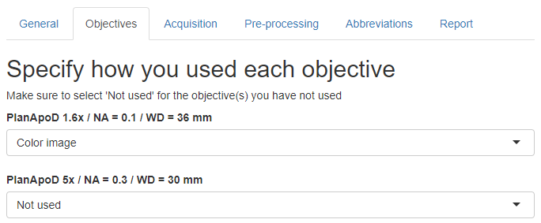

> *Objectives tab for the Smartzoom 5.*

Below the fields to assign uses to objectives, a barplot shows the lateral optical resolutions of each used objective. For the Axio Imager.Z2 Vario + LSM 800 MAT, you have the choice for the wavelength of the light source (`Violet laser (405 nm) - LSM` for the LSM 800 MAT or `White LED (550 nm) - WF` for the Axio Imager.Z2 Vario) but only the latter is available for the Smartzoom 5.  
The graph can be exported to PDF or PNG using the buttons below.

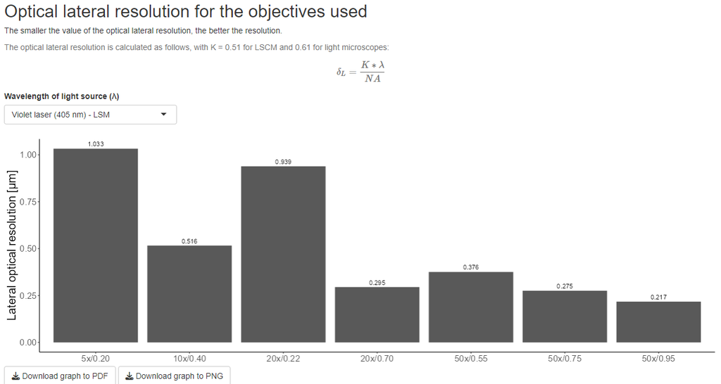

> *Graph of lateral optical resolution for each used objective, with download buttons.*

## Tab “Acquisition”

WIP

## Tab “Pre-processing”

**Enter the options of the pre-processing methods in this tab.**  
Only a 2D acquisition does not require pre-processing. So if you did not select anything else than “2D” in the tab “General”, no input is needed in the tab “Pre-processing” and a message notifies you of this.

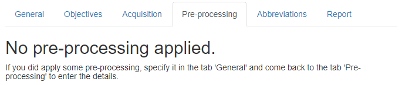

> *No information on pre-processing is needed.*

Different fields to fill in appear depending on instrument used and on the acquisition modes applied.

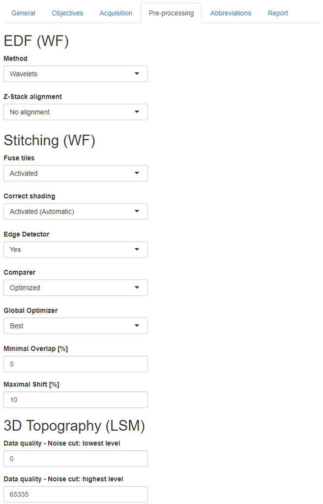

> *Pre-processing tab for the Axio Imager.Z2 Vario + LSM 800 MAT.*

Specific to the Smartzoom, if you applied EDF/3D, use the slider to specify the range of number of slices you used (minimum to maximum) for the stacking.

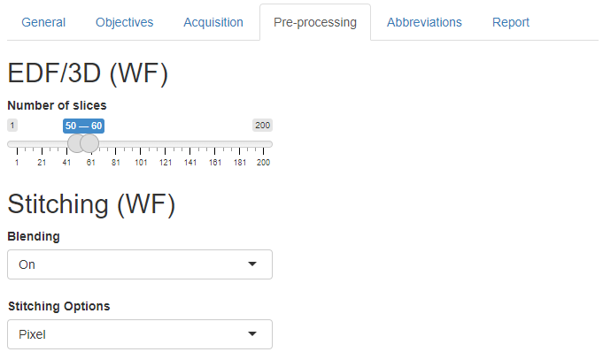

> *Pre-processing tab for the Smartzoom 5.*

## Tab “Abbreviations”

**This tab lists the abbreviations used in other places of the App.**

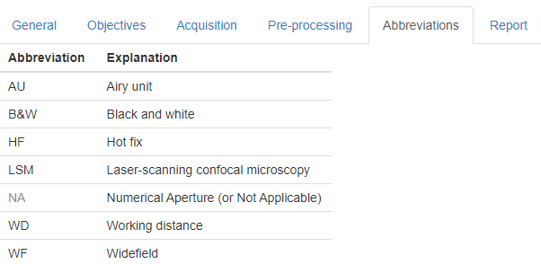

> *Abbreviations tab.*

## Tab “Report”

**This tab shows a preview of the entered information.**  
I recommend that you check that everything is correct before you download the report (see below).  
As mentioned already here, it can be that some fields are not updated in this tab. In such cases, go back to the beginning (side bar) and follow the tabs from left (General) to right (Pre-processing).  
Once done, click on the `Download Report to ODS` or `Download Report to XLSX` buttons at the bottom of the tab. Save the file to your computer; I recommend to use the name provided. **Check the file.**

**Save one report for each instrument you used.**

*WIP: Screenshots will be added later.*

# How to adapt the App

I have tried to make the code of the App as clear as possible and to comment it as much as possible. This is surely not perfect, especially because the code is long and imbricated, but I hope this will be enough for future developments and adaptations.

If you would like to adapt the App to your instrument(s), feel free to do so on your own (see section Download the repository). Nevertheless, **I would appreciate if you would be willing to contribute**! You can also get in touch with me directly.

# How to contribute

I appreciate any comment from anyone (expert or novice) to improve this App, so do not be shy!  
There are three possibilities to contribute.

1. Submit an issue: If you notice any problem or have a question, submit an [issue](https://docs.github.com/en/issues/tracking-your-work-with-issues/about-issues). You can do so [here](https://github.com/ivan-paleo/reporting-templates/issues).
2. Propose changes: If you know how to write a [Shiny App](https://shiny.rstudio.com/), please propose text edits as a [pull request](https://docs.github.com/en/pull-requests/collaborating-with-pull-requests/proposing-changes-to-your-work-with-pull-requests/about-pull-requests) (abbreviated “PR”).
3. Send me an email: For options 1-2, you need to create a GitHub account. If you do not have one and do not want to sign up, you can still write me an email (Google me to find my email address).

By participating in this project, you agree to abide by our code of conduct.

# License

[figure not shown]

This work is licensed under a [Creative Commons Attribution-NonCommercial-ShareAlike 4.0 International License](http://creativecommons.org/licenses/by-nc-sa/4.0/). See LICENSE.

Author: Ivan Calandra

*License badge, file and image from Soler S. cc-licenses: Creative Commons Licenses for GitHub Projects, https://github.com/santisoler/cc-licenses.*